# Visualization: ggplot

2023-09-28

```r
library(tidyverse)
```

```r
library(ggridges)

knitr::opts_chunk$set(
  fig.width = 6,
  fig.asp = .6,
  out.width = "90%"
)

weather_df =
  rnoaa::meteo_pull_monitors(
    c("USW00094728", "USW00022534", "USS0023B17S"),
    var = c("PRCP", "TMIN", "TMAX"),
    date_min = "2021-01-01",
    date_max = "2022-12-31") |>
  mutate(
    name = recode(
      id,
      USW00094728 = "CentralPark_NY",
      USW00022534 = "Molokai_HI",
      USS0023B17S = "Waterhole_WA"),
    tmin = tmin / 10,
    tmax = tmax / 10) |>
  select(name, id, everything())
```

[output not shown]

# Basic scatterplot

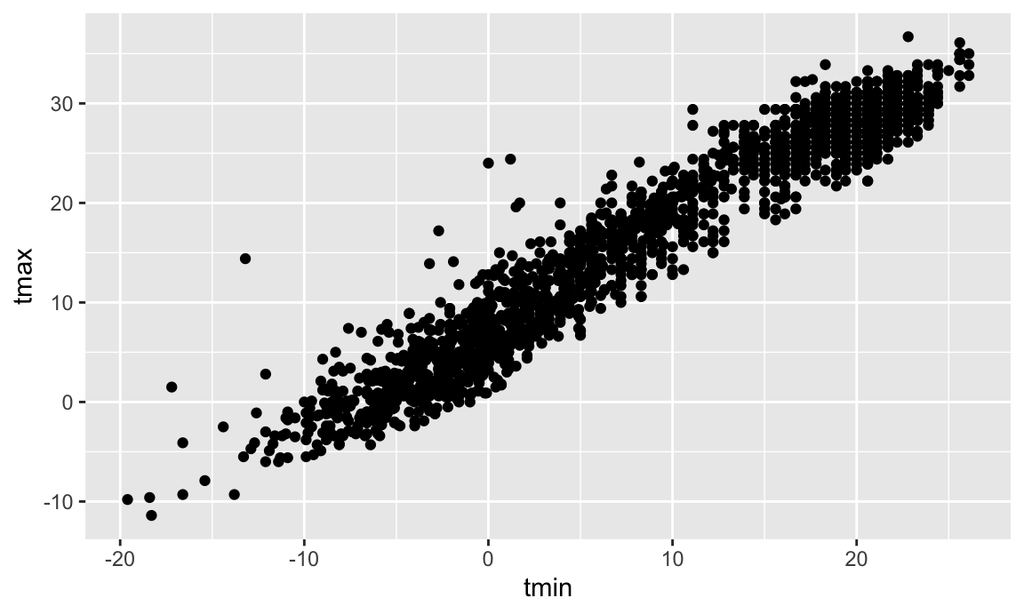

```r
ggplot(weather_df, aes(x = tmin, y = tmax)) +
  geom_point()
```

You can also take/start with the df and pipe the scatterplot, and it will create exactly the same plot:

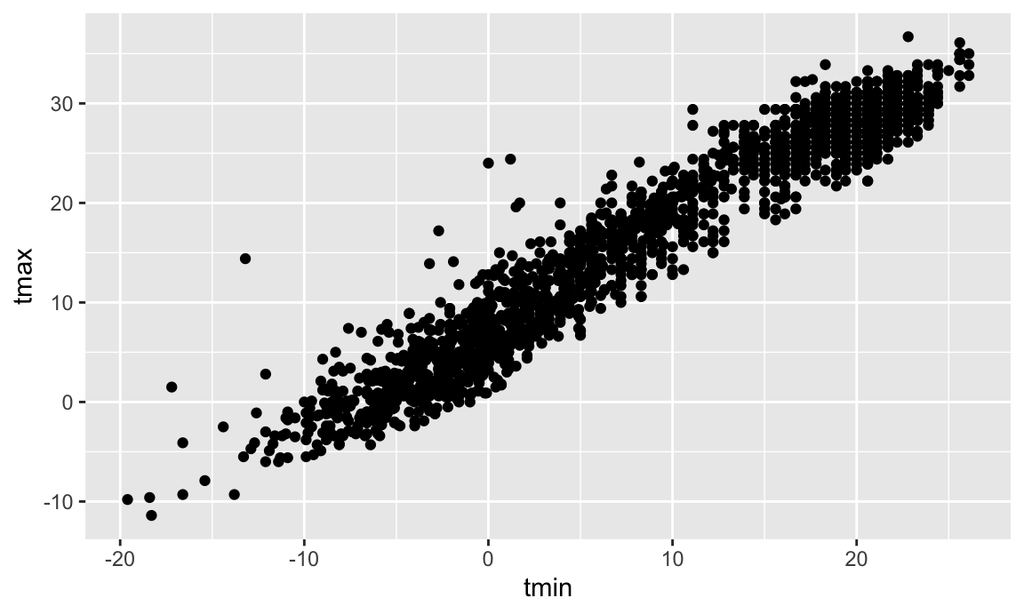

```r
weather_df |>
  ggplot(aes(x = tmin, y = tmax)) +
  geom_point()
```

Piping may make filtering easier. You don’t have to create a separate df just for New York, for example:

[figure not shown]

```r
nyc_weather =
  weather_df |>
  filter(name == "CentralParkNY") |>
  ggplot(aes(x = tmin, y = tmax)) +
  geom_point()

nyc_weather + geom_point()
```

# Fancy plot

color can be added to the entire plot in ggplot or to the points in geom_point

geom_smooth adds a smooth curve

se = FALSE removes standard error bars from the curve

alpha blending/shading make the points more transparent (0.3 = 30% solid 70% opaque)

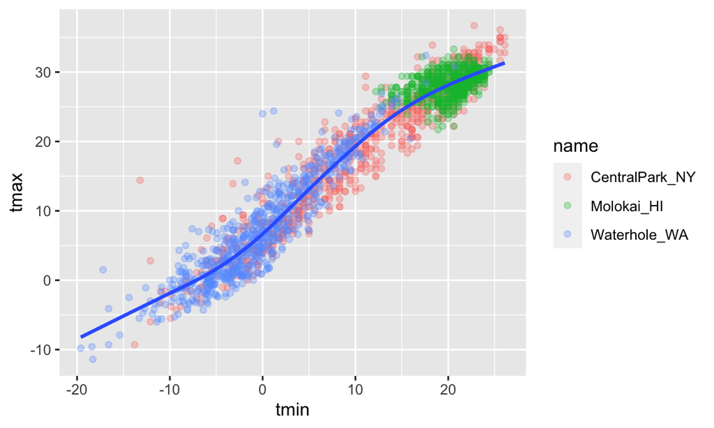

```r
ggplot(weather_df, aes(x = tmin, y = tmax)) +
  geom_point(aes(color = name), alpha = 0.3) +
  geom_smooth(se = FALSE)
```

Plot with facets:

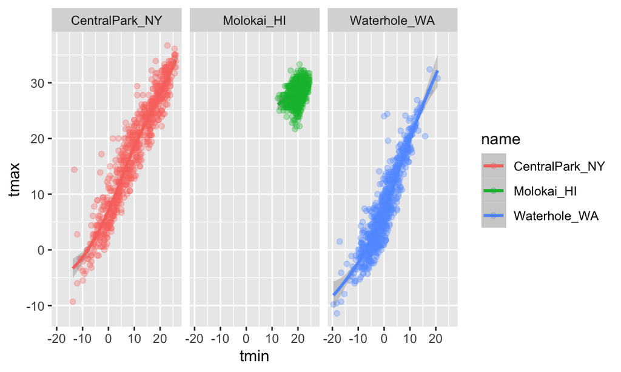

```r
ggplot(weather_df, aes(x = tmin, y = tmax, color = name)) +
  geom_point(alpha = 0.3) +
  geom_smooth() +
  facet_grid(. ~ name)
```

Another fancy plot:

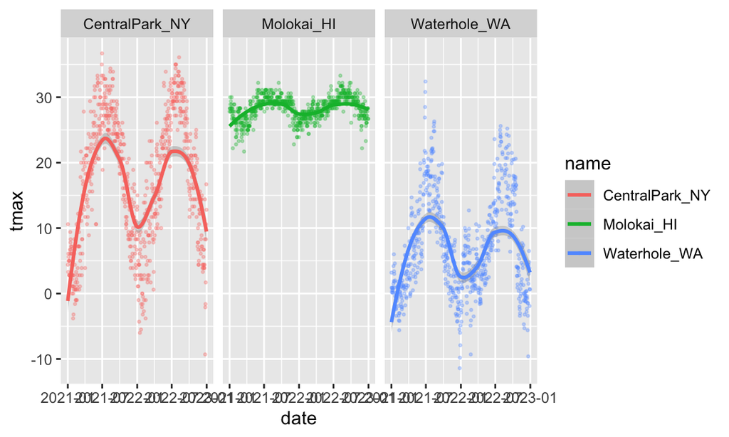

```r
ggplot(weather_df, aes(x = date, y = tmax, color = name)) +
  geom_point(aes(size = prcp), alpha = 0.3, size = 0.5) +
  geom_smooth() +
  facet_grid(. ~ name)
```

Assigning specific colors to specific things:

Need to assign the color in geom_point, not ggplot because aesthetic mappings takes variables from your dataset and maps them onto colors

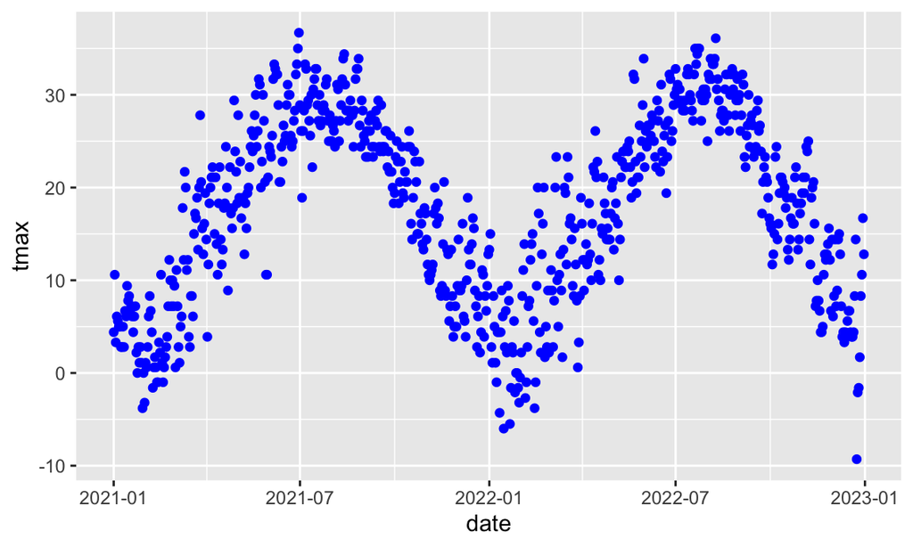

```r
weather_df |>
  filter(name == "CentralPark_NY") |>
  ggplot(aes(x = date, y = tmax)) +
  geom_point(color = "blue")
```

Hex plot:

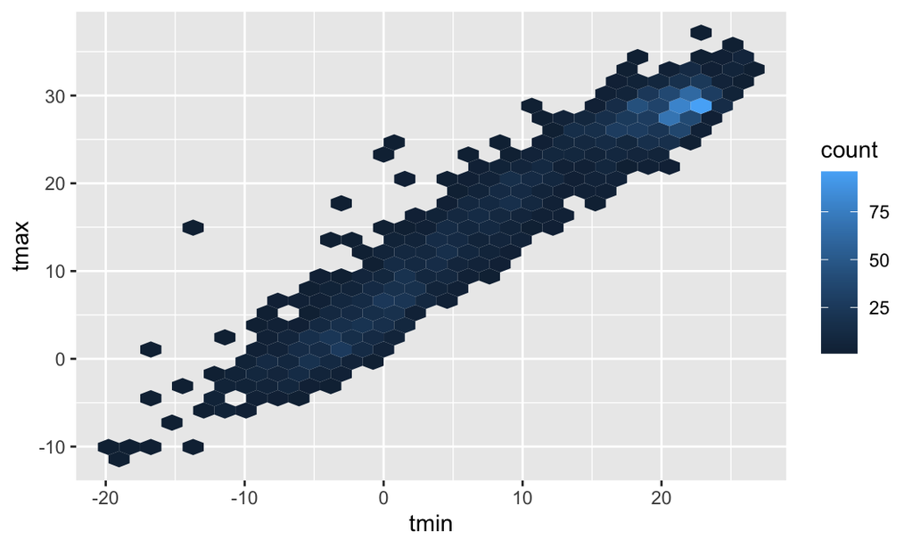

```r
weather_df |>
  ggplot(aes(x = tmin, y = tmax)) +
  geom_hex()
```

Line plot:

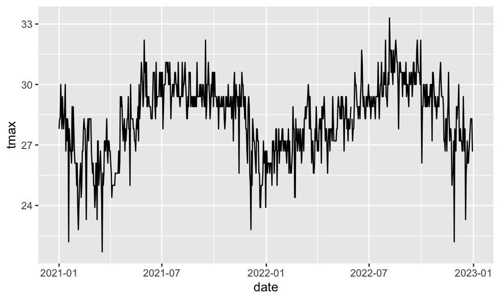

```r
weather_df |>
  filter(name == "Molokai_HI") |>
  ggplot(aes(x = date, y = tmax)) +
  geom_line()
```

Can combine line plot with points:

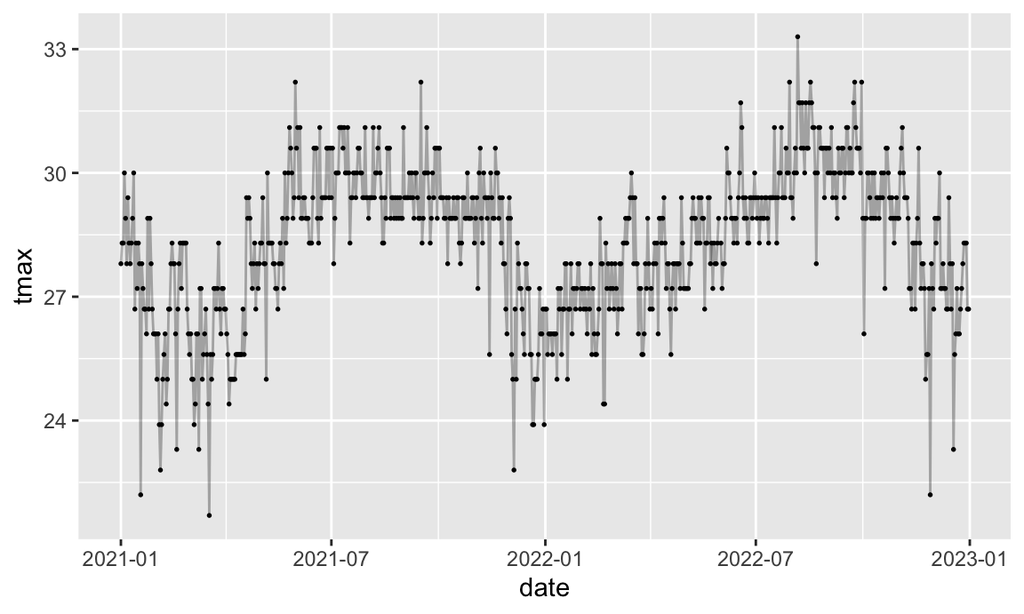

```r
weather_df |>
  filter(name == "Molokai_HI") |>
  ggplot(aes(x = date, y = tmax)) +
  geom_line(alpha = 0.3) +
  geom_point(size = 0.3)
```

# Univariate plotting

Easiest starting point for this is a basic histogram:

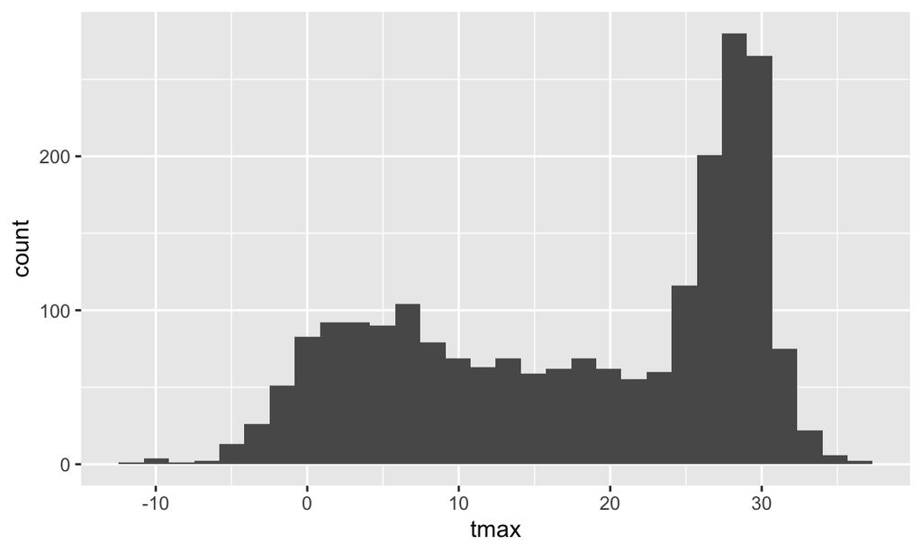

```r
ggplot(weather_df, aes(x = tmax)) +
  geom_histogram()
```

fill argument fills in colors for histogram

position = “dodge” places bars for each group side-by-side - bars should avoid each other rather than stack up on each other (however, this can get difficult –> easier to use density plots)

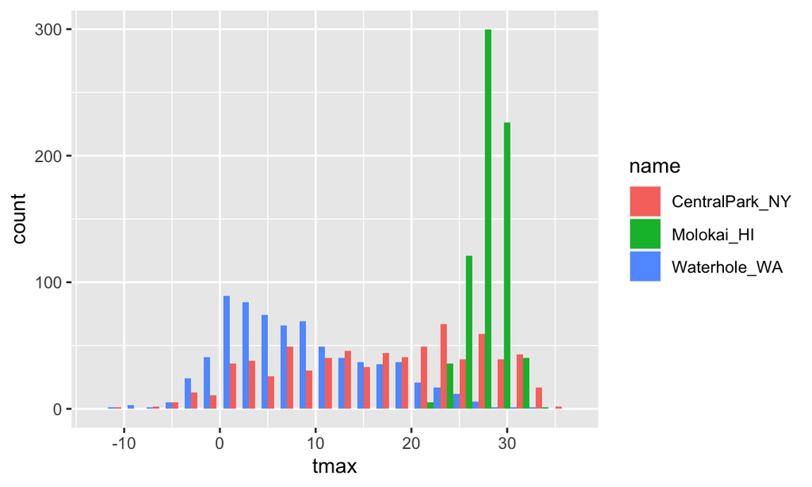

```r
ggplot(weather_df, aes(x = tmax, fill = name)) +
  geom_histogram(position = "dodge", binwidth = 2)
```

Density plot:

adjust argument is similar to binwidth in histograms

if you over-smooth or under-smooth, you may miss the message you’re trying to make

density plots show more distribution than box plots

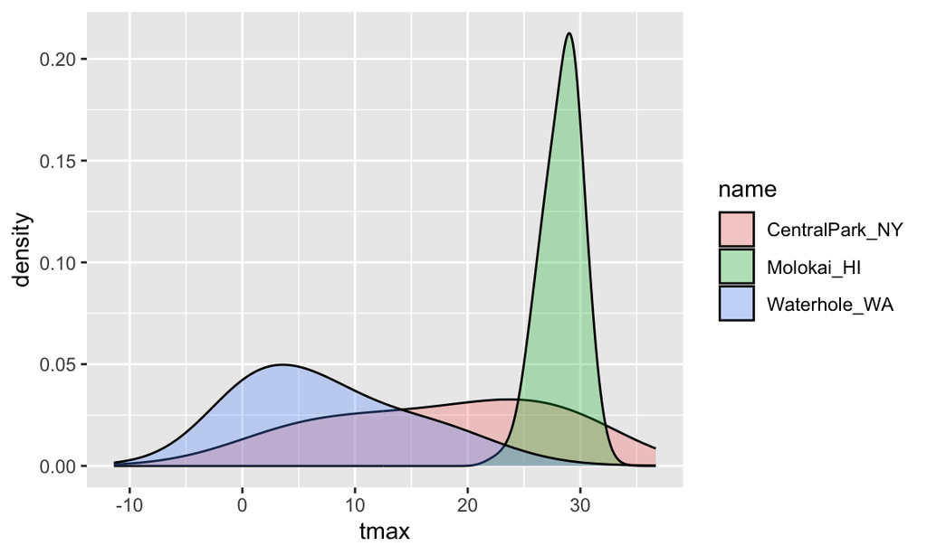

```r
ggplot(weather_df, aes(x = tmax, fill = name)) +
  geom_density(alpha = 0.3, adjust = 2)
```

Basic boxplots:

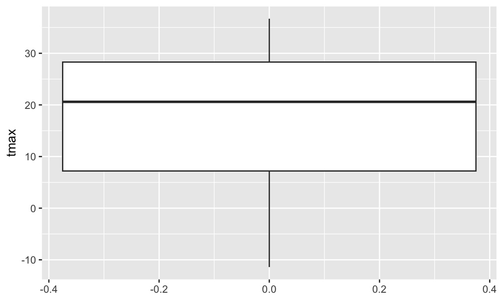

```r
ggplot(weather_df, aes(y = tmax)) +
  geom_boxplot()
```

Can compare by group, e.g., name:

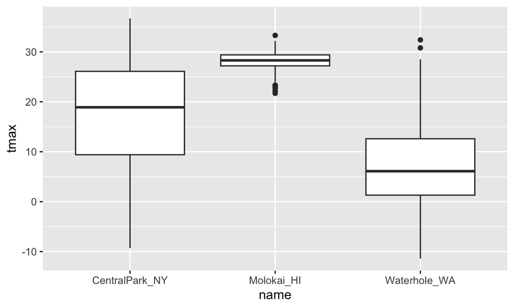

```r
ggplot(weather_df, aes(x = name, y = tmax)) +
  geom_boxplot()
```

Violin plot:

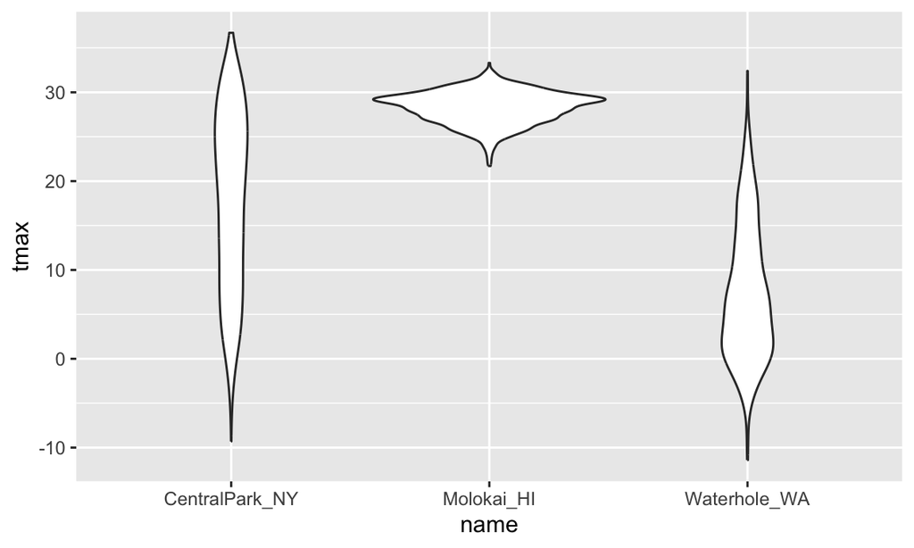

```r
ggplot(weather_df, aes(x = name, y = tmax)) +
  geom_violin()
```

Ridge plot:

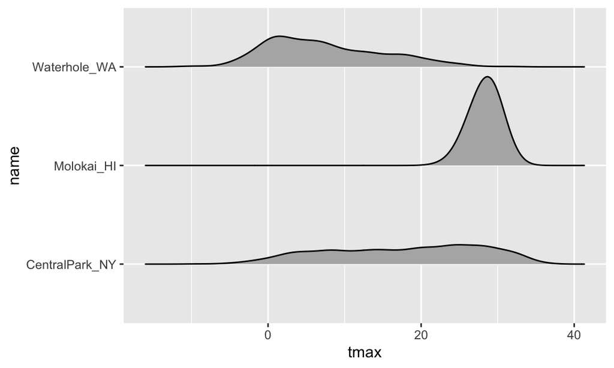

```r
ggplot(weather_df, aes(x = tmax, y = name)) +
  geom_density_ridges(scale = 0.9)
```

# Saving and embedding plots

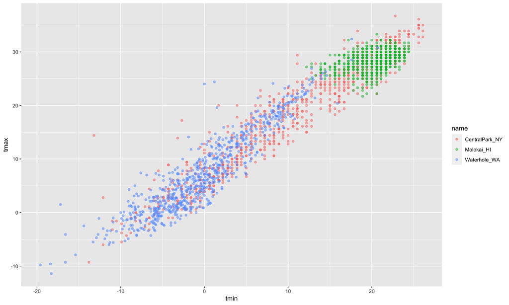

```r
ggp_weather =
  ggplot(weather_df, aes(x = tmin, y = tmax)) +
  geom_point(aes(color = name), alpha = 0.5)

ggsave("ggp_weather.pdf", ggp_weather, width = 8, height = 5)
ggp_weather
```

You can also set options globally in the beginning after loading packages with this code:

knitr::opts_chunk$set( fig.width = 6, fig.asp = .6, out.width = “90%” )

fig.asp = aspect ratio